# Modeling SP500 daily returns

Andrea Schioppa

## Synopsis

We use the data set sp500.dta available from [Verbeek’s data sets](http://bcs.wiley.com/he-bcs/Books?action=resource&bcsId=7080&itemId=1119951674&resourceId=27088) (Chapter 8), which contains daily returs on the SP500 index from January 1981 to April 1991 ($T = 2783$), to illustrate the choice of an autoregressive model.

## Loading the data and creating a plot

```r
library(foreign)
library(ggplot2)
library(lubridate)
library(scales)
library(zoo)
library(forecast)
library(rugarch)
```

We load the data and make a plot. Note the October 19, 1987 crash.

```r
sp500 <- read.dta('../sp500.dta')
```

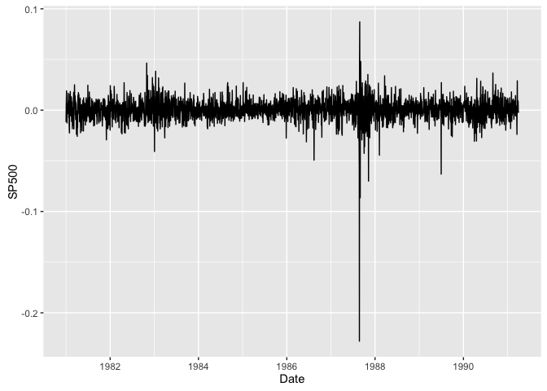

```r
sp500$T <- c(1:dim(sp500)[1])
sp500$date <- seq(as.Date('1981-01-01'), as.Date('1991-04-01'), length.out = dim(sp500)[1])

p <- ggplot(sp500, aes(x=date, y=r500)) + geom_line()
p <- p + labs(x = 'Date', y ='SP500')
p
```

We also make a plot of the autocorrelation and the partial autocorrelations.

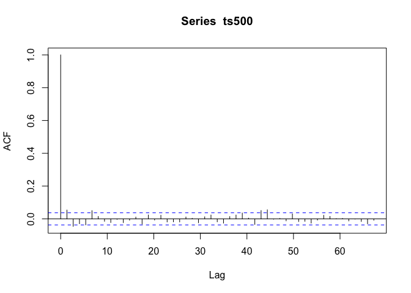

```r
# convert to time series
ts500 <- zoo(sp500$r500, sp500$date)

# auto/partial correlation
acf_ts500 <- acf(ts500, lag.max = 50) # exclude autocorrelation
```

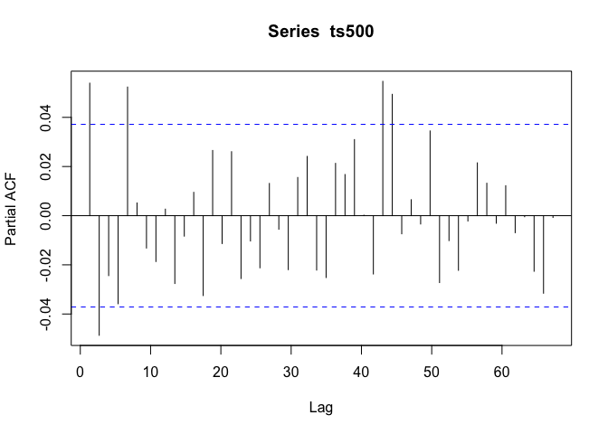

```r
pacf_ts500 <- pacf(ts500, lag.max = 50)
```

From the autocorrelation we decide to exclude moving average terms.

## Fitting AR(p) models

We fit AR(p) models for $p\in\{1,\ldots,7\}$. We then compute p-values for individual coefficients under a normality assumption (it might be more rigorous to estimate robust errors).

```r
# fit AR(1)--AR(7) models
armodels <- list()
for(i in 1:7) {
    armodels[[paste('AR(', i, ')', sep = '')]] <- arima(ts500, order = c(i,0,0))
}

# construct pvals for individual coefficients
# note: we compute asymmetric ones, with just one tail
arpvals <- lapply(armodels, function(x) {
    out <- data.frame(z = x$coef/sqrt(diag(x$var.coef)), row.names = names(x$coef))
    out$pval = pnorm(abs(out$z), lower.tail=F)
    out
}) # based

arpvals
```

```
## $`AR(1)`
##                  z        pval
## ar1       2.848970 0.002193049
## intercept 1.918749 0.027508038
##
## $`AR(2)`
##                   z        pval
## ar1        2.986477 0.001411062
## ar2       -2.570393 0.005079154
## intercept  2.013881 0.022011023
##
## $`AR(3)`
##                   z        pval
## ar1        2.921203 0.001743413
## ar2       -2.494150 0.006312959
## ar3       -1.288115 0.098852896
## intercept  2.060776 0.019662215
##
## $`AR(4)`
##                   z        pval
## ar1        2.878055 0.002000677
## ar2       -2.582013 0.004911297
## ar3       -1.183267 0.118351772
## ar4       -1.893564 0.029141455
## intercept  2.129580 0.016603133
##
## $`AR(5)`
##                   z        pval
## ar1        2.980949 0.001436785
## ar2       -2.524706 0.005789761
## ar3       -1.049208 0.147041180
## ar4       -2.044245 0.020464694
## ar5        2.768462 0.002816078
## intercept  2.024080 0.021480968
##
## $`AR(6)`
##                    z        pval
## ar1        2.9624337 0.001526087
## ar2       -2.5119097 0.006003991
## ar3       -1.0437939 0.148290384
## ar4       -2.0290672 0.021225726
## ar5        2.7485996 0.002992523
## ar6        0.2754552 0.391483252
## intercept  2.0145324 0.021976833
##
## $`AR(7)`
##                    z        pval
## ar1        2.9649474 0.001513673
## ar2       -2.4733860 0.006691975
## ar3       -1.0695243 0.142416734
## ar4       -2.0415430 0.020598445
## ar5        2.7129510 0.003334349
## ar6        0.3140153 0.376754693
## ar7       -0.6924430 0.244329574
## intercept  2.0441455 0.020469586
```

From the list AR(5) seems a reasonable guess. The function `Constraint_Test` implements joint significance tests for the coefficients. The tests are Lagrange Multiplier (LM), LogLikelihood Ratio (LR) and Wald (W). The lexicographic ordering $\text{LM}\le\text{LR}\le\text{W}$ holds.

```r
# construct pvals for joint testing
Constraint_Test <- function(x, sigma2) {
    N.obs <- x$nobs
    N.df <- length(x$coef) - 1

    out <- data.frame(Stat = c(N.obs * (sigma2-x$sigma2) / sigma2,
                               N.obs * log(sigma2 / x$sigma2),
                               N.obs * (sigma2-x$sigma2) / x$sigma2))
    rownames(out) <- c('LM', 'LR', 'W')
    out$Pval <- apply(out, 1, pchisq, df = N.df, lower.tail = FALSE)

    out
}

ar_joint_pvals <- lapply(armodels, Constraint_Test, sigma2 = var(sp500$r500))
ar_joint_pvals
```

```
## $`AR(1)`
##        Stat        Pval
## LM 9.092170 0.002567061
## LR 9.107055 0.002546255
## W  9.121972 0.002525575
##
## $`AR(2)`
##        Stat         Pval
## LM 15.66727 0.0003961835
## LR 15.71153 0.0003875110
## W  15.75597 0.0003789967
##
## $`AR(3)`
##        Stat         Pval
## LM 17.31804 0.0006078844
## LR 17.37215 0.0005924911
## W  17.42649 0.0005774236
##
## $`AR(4)`
##        Stat         Pval
## LM 20.88208 0.0003341793
## LR 20.96082 0.0003223842
## W  21.03995 0.0003109454
##
## $`AR(5)`
##        Stat         Pval
## LM 28.48084 2.930963e-05
## LR 28.62758 2.743272e-05
## W  28.77532 2.566343e-05
##
## $`AR(6)`
##        Stat         Pval
## LM 28.55611 7.380455e-05
## LR 28.70362 6.921750e-05
## W  28.85215 6.488383e-05
##
## $`AR(7)`
##        Stat         Pval
## LM 29.03179 0.0001427683
## LR 29.18428 0.0001339083
## W  29.33784 0.0001255343
```

## Ljung-Box Test

We implement a Ljung-Box Test for the residuals of the models we fitted. The goal is to detect significant autocorrelations. The Ljung-Box test statistic is a $\chi^2$ with the degrees of freedom depending on how many lagged autocorrelations ($K$) we use. Note that if $K$ is too small the statistic is `NA`. We used $K=6, 12, 18$. The null-hypothesis of the test is that errors are not serially correlated. There seems to be evidence that 5-lags are needed to uncorrelate the errors.

```r
Ljung_Box_Test <- function(x, K) {
    T <- x$nobs
    ndf <- K - (length(x$coef) - 1)
    if(ndf <= 0 || T <= K) return(NA) # can't apply the statistics

    # autocorrelations
    rk <- acf(x$residuals, lag.max = K, plot = FALSE)
    rk <- as.numeric(rk$acf)[-1] # first is lag = 0


    # weights
    wk <- 1/(T-c(1:K))

    # Q-statistic
    Q <- T * (T+2) * sum(wk * rk^2)

    return(pchisq(Q, df = ndf, lower.tail = FALSE))
}

Kvec <- c(6, 12, 18)
arlj_pvals <- matrix(0, nrow = length(armodels), ncol = length(Kvec))
rownames(arlj_pvals) <- names(armodels)
colnames(arlj_pvals) <- paste('K =', Kvec)

for(i in 1:length(Kvec)) {
    arlj_pvals[,i] <- sapply(armodels, Ljung_Box_Test, K = Kvec[i])
}

arlj_pvals
```

```
##            K = 6     K = 12     K = 18
## AR(1) 0.00125624 0.01312866 0.01285038
## AR(2) 0.01246906 0.08025672 0.05218655
## AR(3) 0.01147620 0.08716261 0.06285550
## AR(4) 0.02509906 0.17271094 0.10480447
## AR(5) 0.80593338 0.74419850 0.41097346
## AR(6)         NA 0.64322671 0.33756376
## AR(7)         NA 0.56918417 0.28960356
```

## Information Criteria

To assist in choosing a model we apply the AIC/BIC criteria.

```r
ar_infcr <- matrix(0, nrow = length(armodels), ncol = 2)
rownames(ar_infcr) <- names(armodels)
colnames(ar_infcr) <- c('AIC', 'BIC')
ar_infcr[, 1] <- unlist(sapply(armodels, `[`, 'aic'))
ar_infcr[, 2] <- sapply(armodels, BIC)

ar_infcr
```

```
##             AIC       BIC
## AR(1) -17276.95 -17259.16
## AR(2) -17281.55 -17257.83
## AR(3) -17281.21 -17251.55
## AR(4) -17282.79 -17247.21
## AR(5) -17288.45 -17246.93
## AR(6) -17286.52 -17239.07
## AR(7) -17285.00 -17231.62
```

AIC suggests AR(5) while BIC AR(1), but we know that AR(1) fails to eliminate the serial correlation in the residuals. We go for AR(5), but we saw before that not all coefficients seem significant. So we fit nested models to make a choice.

```r
arnewmod <- list()
arnewmod[[1]] <- arima(ts500, order = c(5,0,0), fixed = c(NA, 0, 0, 0, NA, NA)) # NA = free;
# last is intercept
arnewmod[[2]] <- arima(ts500, order = c(5,0,0), fixed = c(NA, NA, 0, 0, NA, NA))
arnewmod[[3]] <- arima(ts500, order = c(5,0,0), fixed = c(NA, NA, NA, 0, NA, NA))
arnewmod[[4]] <- arima(ts500, order = c(5,0,0))

# construct pvals for individual coefficients
arnewpvals <- lapply(arnewmod, function(x) {
    null.coef <- which(x$coef == 0)
    if(length(null.coef)>0) {
        out <- data.frame(z = x$coef[-null.coef]/sqrt(diag(x$var.coef)), row.names = names(x$coef[-null.coef]))
    } else {
        out <- data.frame(z = x$coef/sqrt(diag(x$var.coef)), row.names = names(x$coef))
    }
    out$pval = pnorm(abs(out$z), lower.tail=F)
    out
})

arnewpvals
```

```
## [[1]]
##                  z        pval
## ar1       2.952700 0.001575041
## ar5       2.778965 0.002726617
## intercept 1.807430 0.035347595
##
## [[2]]
##                   z        pval
## ar1        3.084528 0.001019378
## ar2       -2.500121 0.006207540
## ar5        2.714225 0.003321555
## intercept  1.902785 0.028534329
##
## [[3]]
##                   z        pval
## ar1        3.023188 0.001250635
## ar2       -2.431999 0.007507876
## ar3       -1.167528 0.121498572
## ar5        2.658996 0.003918689
## intercept  1.948318 0.025688477
##
## [[4]]
##                   z        pval
## ar1        2.980949 0.001436785
## ar2       -2.524706 0.005789761
## ar3       -1.049208 0.147041180
## ar4       -2.044245 0.020464694
## ar5        2.768462 0.002816078
## intercept  2.024080 0.021480968
```

```r
arnew_infcr <- matrix(0, nrow = length(arnewmod), ncol = 2)
rownames(arnew_infcr) <- names(arnewmod)
colnames(arnew_infcr) <- c('AIC', 'BIC')
arnew_infcr[, 1] <- unlist(sapply(arnewmod, `[`, 'aic'))
arnew_infcr[, 2] <- sapply(arnewmod, BIC)

arnew_infcr
```

```
##            AIC       BIC
## [1,] -17282.66 -17258.94
## [2,] -17286.91 -17257.25
## [3,] -17286.27 -17250.68
## [4,] -17288.45 -17246.93
```

The AIC suggests the model with all coefficients unconstrained while the BIC with the second, third and fourth to zero. On the other hand, at $1\%$-significance (we choose this because we are not using robust standard errors) the coefficient of the second term is significant. Finally also the intercept does not appear significant. Hence we fit as final model the one with only the third and fourth coefficients set to $0$ and without an intercept. We compare it with the choice made by the automatic algorithm selection in the `forecast` package.

```r
# Use Hyndman's automatic selection
hyndman_choice <- auto.arima(ts500, max.p = 7, max.q = 0)
# chooses an AR(2)

# My choice
arfinal <- arima(ts500, order = c(5,0,0), fixed = c(NA, NA, 0, 0, NA, 0))
hyndman_choice
```

```
## Series: ts500
## ARIMA(2,0,0) with non-zero mean
##
## Coefficients:
##          ar1      ar2  intercept
##       0.0565  -0.0487      4e-04
## s.e.  0.0189   0.0189      2e-04
##
## sigma^2 estimated as 0.0001173:  log likelihood=8644.78
## AIC=-17281.55   AICc=-17281.54   BIC=-17257.83
```

```r
arfinal
```

```
##
## Call:
## arima(x = ts500, order = c(5, 0, 0), fixed = c(NA, NA, 0, 0, NA, 0))
##
## Coefficients:
##          ar1      ar2  ar3  ar4     ar5  intercept
##       0.0597  -0.0459    0    0  0.0528          0
## s.e.  0.0189   0.0189    0    0  0.0189          0
##
## sigma^2 estimated as 0.0001172:  log likelihood = 8646.63,  aic = -17285.27
```

## The Breutsch-Pagan Test

We now test for autoregressive heteroskedasticity in the residuals. If errors are heteroskedastic, we need more efficient estimators. We implement the Breutsch-Pagan Test; we first tried to use `arima` to write less code, but it gave the wrong results, so we explicitly implement the regressions. The relative statistic compares each model with the previous one.

```r
BreutschPagan <- function(model, p = 7) { # test up to AR(p) in res^2
    res2 <- model$residuals^2
    T <- model$nobs

    bpModels <- list()
    for(i in 1:p) {
        bpModels[[i]] <- arima(res2, order = c(i, 0, 0))
    }

    sigma2 <- var(res2)

    out <- matrix(0, nrow = p, ncol = 4)
    rownames(out) <- paste('HetAR(', c(1:p), ')', paste = '')
    colnames(out) <- c('Stat', 'Pval', 'RelStat', 'RelPval') # Rel = 1 model compared to the previous one

    out[,'Stat'] <- T * (sigma2 - sapply(bpModels, `[[`, 'sigma2')) / sigma2
    out[, 'Pval'] <- pchisq(out[,'Stat'], df = c(1:p), lower.tail = FALSE) # vectorize pchisq

    out[1, 'RelStat'] <- NA
    out[1, 'RelPval'] <- NA

    out[-1, 'RelStat'] <- T * (sapply(bpModels, `[[`, 'sigma2')[-p] - sapply(bpModels, `[[`, 'sigma2')[-1]) / (
        sapply(bpModels, `[[`, 'sigma2')[p])
    out[-1, 'RelPval'] <- pchisq(out[-1,'RelStat'], df = 1, lower.tail = FALSE) # vectorize pchisq

    out
}

arBP <- BreutschPagan(model = arfinal, p = 10)

arBP
```

```
##                   Stat         Pval     RelStat      RelPval
## HetAR( 1 )    50.95870 9.433022e-13          NA           NA
## HetAR( 2 )    79.56858 5.271109e-18 29.88708888 4.579522e-08
## HetAR( 3 )    84.95043 2.659484e-18  5.62209967 1.773539e-02
## HetAR( 4 )    85.01184 1.508210e-17  0.06415717 8.000421e-01
## HetAR( 5 )   112.36263 1.297358e-22 28.57178089 9.028846e-08
## HetAR( 6 )   112.38823 6.441856e-22  0.02674662 8.700902e-01
## HetAR( 7 )   112.92062 2.273478e-21  0.55615385 4.558141e-01
## HetAR( 8 )   117.52294 1.075720e-21  4.80777765 2.833156e-02
## HetAR( 9 )   118.31693 2.952792e-21  0.82943627 3.624356e-01
## HetAR( 10 )  118.92940 8.343232e-21  0.63980647 4.237809e-01
```

If we want to use a regressive heteroskedasticity model we should use at least $5$ lags.

## ARCH(5)-model

```r
# Heteroskedasticity seems significant up to order 5

# specify model; sGARCH = plain GARCH
archSpec <- ugarchspec(variance.model = list(model = 'sGARCH', garchOrder = c(0,5)),
                       mean.model = list(armaOrder = c(5,0)))
# add constraints mu = ar3 = ar4 = 0
setfixed(archSpec)<-list(mu = 0, ar3=0, ar4=0)
# fit
archmod <- ugarchfit(archSpec, data = ts500)

# compare result
print(archmod@fit$coef)
```

```
##            mu           ar1           ar2           ar3           ar4
##  0.000000e+00  6.221021e-02 -4.426587e-02  0.000000e+00  0.000000e+00
##           ar5         omega         beta1         beta2         beta3
##  5.484528e-02  1.340904e-07  2.136219e-01  2.092184e-01  2.018429e-01
##         beta4         beta5
##  1.929215e-01  1.813896e-01
```

```r
print(archmod@fit$se.coef)
```

```
## [1] 1.889487e-02 1.887188e-02 1.886436e-02 2.706810e-07 7.587343e-05
## [6] 7.609136e-05 7.410537e-05 7.526228e-05 7.564202e-05
```

```r
print(arfinal$coef)
```

```
##         ar1         ar2         ar3         ar4         ar5   intercept
##  0.05974372 -0.04591755  0.00000000  0.00000000  0.05276654  0.00000000
```

```r
print(sqrt(diag(arfinal$var.coef)))
```

```
##        ar1        ar2        ar5
## 0.01892000 0.01891171 0.01890147
```

We see an agreement of the coefficients and their standard errors in the two models.

## GARCH(1,1)-model

We now fit a GARCH(1,1)-model. The smoothing term would have the efferct of needing less autoregressive terms.

```r
# specify
garchSpec <- ugarchspec(variance.model = list(model = 'sGARCH', garchOrder = c(1,1)),
                        mean.model = list(armaOrder = c(5,0)))
setfixed(garchSpec) <- list(mu = 0, ar3 = 0, ar4 = 0)
# fit
garchmod <- ugarchfit(garchSpec, data = ts500, solver = 'nloptr', solver.control = list(solver = 9))
# compare result
print(garchmod@fit$coef)
```

```
##            mu           ar1           ar2           ar3           ar4
##  0.000000e+00  7.135195e-02 -8.073072e-03  0.000000e+00  0.000000e+00
##           ar5         omega        alpha1         beta1
##  8.296377e-03  1.944129e-07  5.682719e-02  9.431728e-01
```

```r
print(garchmod@fit$se.coef)
```

```
## [1] 2.038475e-02 2.025126e-02 2.006021e-02 5.973735e-07 6.437823e-03
## [6] 7.017355e-03
```

```r
print(arfinal$coef)
```

```
##         ar1         ar2         ar3         ar4         ar5   intercept
##  0.05974372 -0.04591755  0.00000000  0.00000000  0.05276654  0.00000000
```

```r
print(sqrt(diag(arfinal$var.coef)))
```

```
##        ar1        ar2        ar5
## 0.01892000 0.01891171 0.01890147
```

```r
alpha_beta <- garchmod@fit$coef['alpha1'] + garchmod@fit$coef['beta1']

alpha_beta
```

```
## alpha1
##      1
```

There is less agreement with the coefficients of `arfinal`, in particular for the autoregressive term of order $5$. Note that `alpha1+beta1` is close to $1$, suggesting strong persistence of the shocks.

## EGARCH-model

We finally fit an EGARCH-model. This allows for the sign of the shock to have an effect on the volatility.

```r
# specify
egarchSpec <- ugarchspec(variance.model = list(model = 'eGARCH', garchOrder = c(1,1)),
                        mean.model = list(armaOrder = c(5,0)))
setfixed(egarchSpec) <- list(mu = 0, ar3 = 0, ar4 = 0)
# fit
# tweak the solver for convergence; standard option does NOT converge
egarchmod <- ugarchfit(egarchSpec, data = ts500, solver = 'nloptr', solver.control = list(solver = 9))
# parameter alpha1 = (gamma in Verbeek) < 0: asymmetry of the shocks
# compare result
print(egarchmod@fit$coef)
```

```
##           mu          ar1          ar2          ar3          ar4
##  0.000000000  0.063775227  0.004270203  0.000000000  0.000000000
##          ar5        omega       alpha1        beta1       gamma1
##  0.009538257 -0.328073095 -0.081634208  0.963528773  0.154073877
```

```r
print(egarchmod@fit$se.coef)
```

```
## [1] 0.019892739 0.009904198 0.018048664 0.022001982 0.014392937 0.002340531
## [7] 0.015824977
```

```r
print(arfinal$coef)
```

```
##         ar1         ar2         ar3         ar4         ar5   intercept
##  0.05974372 -0.04591755  0.00000000  0.00000000  0.05276654  0.00000000
```

```r
print(sqrt(diag(arfinal$var.coef)))
```

```
##        ar1        ar2        ar5
## 0.01892000 0.01891171 0.01890147
```

Note that `alpha1` is negative and captures the sign effect (one has to check on the [vignette](https://cran.r-project.org/web/packages/rugarch/vignettes/Introduction_to_the_rugarch_package.pdf), pg. 7). The notation is inconsistent, elsewhere the sign effect is denoted by $\gamma$. Anyway, we see that negative shocks have a greater effect on increasing volatility.

## Final Choice

For the final choice we use the information criteria.

```r
# Summarize infoCriteria

infoSummary <- data.frame(cbind(infocriteria(archmod),infocriteria(garchmod)), infocriteria(egarchmod))
colnames(infoSummary) <- c('ARCH', 'GARCH', 'EGARCH')

infoSummary
```

```
##                   ARCH     GARCH    EGARCH
## Akaike       -6.209602 -6.443092 -6.477095
## Bayes        -6.190421 -6.430305 -6.462176
## Shibata      -6.209623 -6.443102 -6.477108
## Hannan-Quinn -6.202676 -6.438475 -6.471708
```

All criteria prefer the EGARCH model.